# Regressão linear na prática

## Dados da CAPES sobre avaliação da pós-graduação

A CAPES é um órgão do MEC que tem a atribuição de acompanhar a pós-graduação na universidade brasileira. Uma das formas que ela encontrou de fazer isso e pela qual ela é bastante criticada é através de uma avaliação quantitativa a cada x anos (era 3, mudou para 4).

Usaremos dados da penúltima avaliação da CAPES:

```r
cacc = read_projectdata()
glimpse(cacc)
```

```
Observations: 73
Variables: 31
$ Instituição                  <chr> "UNIVERSIDADE FEDERAL DO AMAZONAS", "UNIVERSIDADE FEDERAL DO PARÁ", "UNIVERSIDADE FEDERAL DO MARANHÃO", "UNIVERSIDADE ESTADUAL DO MARANHÃO", "FUN...
$ Programa                     <chr> "INFORMÁTICA (12001015012P2)", "CIÊNCIA DA COMPUTAÇÃO (15001016047P9)", "CIÊNCIA DA COMPUTAÇÃO (20001010022P0)", "ENGENHARIA DE COMPUTAÇÃO E SIST...
$ Nível                        <int> 5, 4, 3, 3, 3, 5, 4, 3, 3, 3, 5, 3, 3, 3, 4, 6, 3, 3, 3, 3, 3, 3, 4, 3, 4, 3, 4, 7, 4, 5, 7, 3, 4, 7, 3, 3, 3, 3, 4, 4, 4, 4, 3, 6, 3, 6, 7, 4, 3...
$ Sigla                        <chr> "UFAM", "UFPA", "UFMA", "UEMA", "FUFPI", "UFC", "UNIFOR", "UECE/Prof", "UECE", "IFCE", "UFRN", "UFRN/Prof", "UERN/UFERSA", "UFPB/J.P", "UFCG", "U...
$ `Tem doutorado`              <chr> "Sim", "Sim", "Não", "Não", "Não", "Sim", "Sim", "Não", "Não", "Não", "Sim", "Não", "Não", "Não", "Sim", "Sim", "Não", "Não", "Não", "Não", "Não"...
$ `Docentes colaboradores`     <dbl> 0.25, 5.50, 3.00, 6.25, 1.75, 2.00, 1.00, 6.25, 2.75, 0.75, 2.25, 2.00, 4.25, 5.00, 9.25, 22.25, 8.50, 3.50, 6.50, 13.75, 5.75, 3.75, 3.00, 0.50,...
$ `Docentes permanentes`       <dbl> 24.75, 14.00, 10.00, 14.00, 9.50, 20.75, 16.00, 15.75, 8.50, 9.00, 26.25, 8.50, 13.50, 20.00, 31.00, 58.50, 32.00, 14.00, 10.75, 12.50, 14.00, 17...
$ `Docentes visitantes`        <dbl> 0.00, 0.00, 0.00, 0.00, 0.00, 0.75, 0.50, 1.00, 0.50, 0.00, 0.00, 0.00, 0.50, 0.00, 0.00, 0.00, 0.00, 0.50, 0.75, 4.00, 0.00, 0.50, 0.00, 0.00, 0...
$ `Resumos em conf`            <int> 20, 23, 15, 5, 4, 10, 6, 136, 0, 24, 27, 4, 30, 20, 5, 14, 49, 63, 33, 3, 8, 3, 17, 14, 19, 6, 23, 69, 46, 33, 29, 5, 9, 29, 0, 1, 47, 21, 10, 7,...
$ `Resumos expandidos em conf` <int> 25, 24, 7, 10, 1, 68, 9, 13, 4, 6, 16, 5, 25, 29, 28, 81, 65, 38, 14, 6, 18, 101, 58, 26, 27, 6, 22, 75, 44, 48, 67, 10, 24, 100, 10, 3, 9, 9, 14...
$ `Artigos em conf`            <int> 390, 284, 115, 73, 150, 269, 179, 0, 120, 92, 389, 60, 127, 322, 338, 763, 585, 132, 255, 79, 185, 124, 277, 255, 230, 130, 336, 359, 288, 504, 3...
$ Dissertacoes                 <int> 108, 77, 50, 25, 31, 75, 60, 129, 45, 3, 108, 12, 94, 108, 104, 433, 92, 26, 71, 93, 23, 54, 0, 41, 8, 41, 110, 154, 101, 110, 146, 55, 89, 213, ...
$ Teses                        <int> 14, 0, 0, 0, 0, 24, 5, 0, 0, 0, 29, 0, 0, 0, 40, 144, 0, 0, 0, 0, 0, 0, 20, 0, 0, 0, 5, 87, 16, 56, 68, 0, 0, 49, 0, 0, 0, 0, 4, 0, 0, 34, 0, 57,...
```

[output cut: 18 more lines]

### Produção e produtividade de artigos

Uma das maneiras de avaliar a produção dos docentes que a CAPES utiliza é quantificando a produção de artigos pelos docentes. Os artigos são categorizados em extratos ordenados (A1 é o mais alto), e separados entre artigos em conferências e periódicos. Usaremos para esse lab a produção em periódicos avaliados com A1, A2 e B1.

```r
cacc = cacc %>%
  mutate(producao = (periodicos_A1 + periodicos_A2 + periodicos_B1),
         produtividade = producao / `Docentes permanentes`,
         mestrados = Dissertacoes,
         doutorados = Teses,
         mestrados_pprof = mestrados / `Docentes permanentes`,
         doutorados_pprof = doutorados / `Docentes permanentes`,
         tem_doutorado = tolower(`Tem doutorado`))
cacc %>%
  filter(`Tem doutorado` == 'Não')
```

| Instituição | Programa | Nível | Sigla | Tem doutorado | Docentes colaboradores | Docentes permanentes | Docentes visitantes | Resumos em conf | Resumos expandidos em conf | Artigos em conf | Dissertacoes | Teses | periodicos_A1 | periodicos_A2 | periodicos_B1 | periodicos_B2 | periodicos_B3 | periodicos_B4 | periodicos_B5 | periodicos_C | periodicos_NA | per_comaluno_A1 | per_comaluno_A2 | per_comaluno_B1 | per_comaluno_B2 | per_comaluno_B3 | per_comaluno_B4 | per_comaluno_B5 | per_comaluno_C | … |
| --- | --- | --- | --- | --- | --- | --- | --- | --- | --- | --- | --- | --- | --- | --- | --- | --- | --- | --- | --- | --- | --- | --- | --- | --- | --- | --- | --- | --- | --- | --- |
| UNIVERSIDADE FEDERAL DO MARANHÃO | CIÊNCIA DA COMPUTAÇÃO (20001010022P0) | 3 | UFMA | Não | 3.00 | 10.00 | 0.00 | 15 | 7 | 115 | 50 | 0 | 5 | 11 | 7 | 2 | 2 | 0 | 8 | 12 | 8 | 0 | 5 | 5 | 1 | 0 | 0 | 4 | 3 | … |
| UNIVERSIDADE ESTADUAL DO MARANHÃO | ENGENHARIA DE COMPUTAÇÃO E SISTEMAS (20002017004P9) | 3 | UEMA | Não | 6.25 | 14.00 | 0.00 | 5 | 10 | 73 | 25 | 0 | 1 | 1 | 3 | 6 | 2 | 3 | 4 | 5 | 11 | 0 | 0 | 2 | 0 | 1 | 0 | 0 | 1 | … |
| FUNDAÇÃO UNIVERSIDADE FEDERAL DO PIAUÍ | CIÊNCIA DA COMPUTAÇÃO (21001014031P2) | 3 | FUFPI | Não | 1.75 | 9.50 | 0.00 | 4 | 1 | 150 | 31 | 0 | 7 | 4 | 6 | 0 | 3 | 3 | 12 | 2 | 12 | 1 | 2 | 2 | 0 | 0 | 2 | 8 | 2 | … |
| UNIVERSIDADE ESTADUAL DO CEARÁ | COMPUTAÇÃO APLICADA (22003010016P9) | 3 | UECE/Prof | Não | 6.25 | 15.75 | 1.00 | 136 | 13 | 0 | 129 | 0 | 0 | 0 | 2 | 0 | 0 | 3 | 2 | 9 | 31 | 0 | 0 | 0 | 0 | 0 | 0 | 0 | 1 | … |
| UNIVERSIDADE ESTADUAL DO CEARÁ | CIÊNCIA DA COMPUTAÇÃO (22003010018P1) | 3 | UECE | Não | 2.75 | 8.50 | 0.50 | 0 | 4 | 120 | 45 | 0 | 3 | 9 | 6 | 0 | 4 | 1 | 6 | 5 | 7 | 1 | 3 | 2 | 0 | 2 | 1 | 4 | 2 | … |
| INSTITUTO FEDERAL DE EDUCAÇÃO, CIÊNCIA E TECNOLOGIA DO CEARÁ | CIÊNCIA DA COMPUTAÇÃO (22008012004P2) | 3 | IFCE | Não | 0.75 | 9.00 | 0.00 | 24 | 6 | 92 | 3 | 0 | 8 | 2 | 4 | 2 | 6 | 6 | 2 | 10 | 14 | 0 | 0 | 0 | 0 | 0 | 3 | 0 | 4 | … |
| UNIVERSIDADE FEDERAL DO RIO GRANDE DO NORTE | ENGENHARIA DE SOFTWARE (23001011071P0) | 3 | UFRN/Prof | Não | 2.00 | 8.50 | 0.00 | 4 | 5 | 60 | 12 | 0 | 0 | 2 | 4 | 0 | 0 | 0 | 0 | 1 | 0 | 0 | 0 | 0 | 0 | 0 | 0 | 0 | 0 | … |
| UNIVERSIDADE DO ESTADO DO RIO GRANDE DO NORTE | CIÊNCIA DA COMPUTAÇÃO - UERN - UFERSA (23002018002P4) | 3 | UERN/UFERSA | Não | 4.25 | 13.50 | 0.50 | 30 | 25 | 127 | 94 | 0 | 6 | 6 | 2 | 0 | 2 | 4 | 4 | 14 | 27 | 0 | 0 | 1 | 0 | 0 | 2 | 2 | 11 | … |
| UNIVERSIDADE FEDERAL DA PARAÍBA/JOÃO PESSOA | INFORMÁTICA (24001015047P4) | 3 | UFPB/J.P | Não | 5.00 | 20.00 | 0.00 | 20 | 29 | 322 | 108 | 0 | 21 | 20 | 11 | 4 | 6 | 5 | 16 | 28 | 26 | 2 | 1 | 5 | 0 | 1 | 0 | 5 | 3 | … |
| UNIVERSIDADE FEDERAL DE PERNAMBUCO | CIÊNCIAS DA COMPUTAÇÃO (25001019062P6) | 3 | UFPE/Prof | Não | 8.50 | 32.00 | 0.00 | 49 | 65 | 585 | 92 | 0 | 70 | 23 | 29 | 6 | 13 | 3 | 18 | 24 | 19 | 1 | 0 | 0 | 0 | 0 | 0 | 1 | 4 | … |

[output cut: 29 more lines]

### EDA

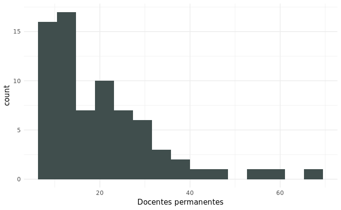

```r
cacc %>%
  ggplot(aes(x = `Docentes permanentes`)) +
  geom_histogram(bins = 15, fill = paleta[1])
```

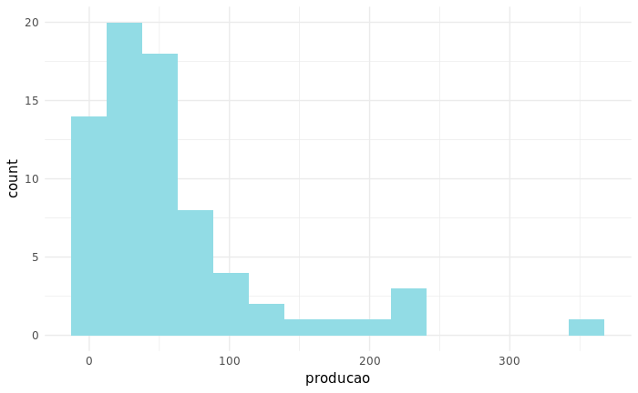

```r
cacc %>%
  ggplot(aes(x = producao)) +
  geom_histogram(bins = 15, fill = paleta[2])
```

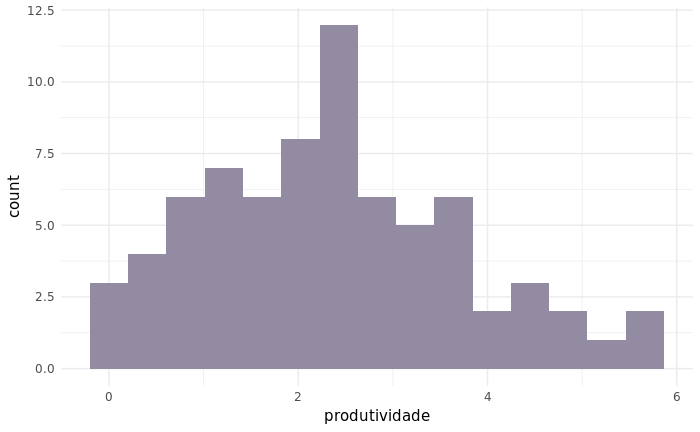

```r
cacc %>%
  ggplot(aes(x = produtividade)) +
  geom_histogram(bins = 15, fill = paleta[3])
```

Se quisermos modelar o efeito do tamanho do programa em termos de docentes (permanentes) na quantidade de artigos publicados, podemos usar regressão.

*Importante*: sempre queremos ver os dados antes de fazermos qualquer modelo ou sumário:

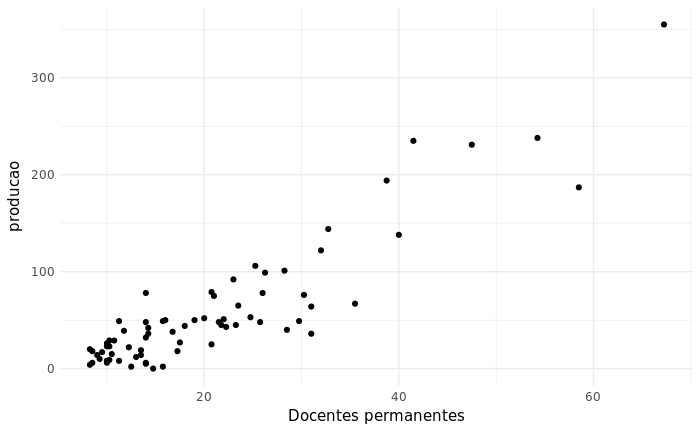

```r
cacc %>%
  ggplot(aes(x = `Docentes permanentes`, y = producao)) +
  geom_point()
```

Parece que existe uma relação. Vamos criar um modelo então:

```r
modelo1 = lm(producao ~ `Docentes permanentes`, data = cacc)
tidy(modelo1, conf.int = TRUE, conf.level = 0.95)
```

| term | estimate | std.error | statistic | p.value | conf.low | conf.high |
| --- | --- | --- | --- | --- | --- | --- |
| (Intercept) | -41.27309 | 6.5299245 | -6.320607 | 2.014731e-08 | -54.293387 | -28.252788 |
| `Docentes permanentes` | 4.81337 | 0.2725331 | 17.661601 | 1.088465e-27 | 4.269955 | 5.356786 |

```r
glance(modelo1)
```

| r.squared | adj.r.squared | sigma | statistic | p.value | df | logLik | AIC | BIC | deviance | df.residual |
| --- | --- | --- | --- | --- | --- | --- | --- | --- | --- | --- |
| 0.8145886 | 0.8119771 | 28.37407 | 311.9322 | 1.088465e-27 | 2 | -346.7883 | 699.5766 | 706.4479 | 57161.22 | 71 |

Para visualizar o modelo:

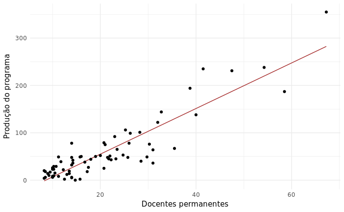

```r
cacc_augmented = cacc %>%
  add_predictions(modelo1)
cacc_augmented %>%
  ggplot(aes(x = `Docentes permanentes`)) +
  geom_line(aes(y = pred), colour = "brown") +
  geom_point(aes(y = producao)) +
  labs(y = "Produção do programa")
```

Se considerarmos que temos apenas uma amostra de todos os programas de pós em CC no Brasil, o que podemos inferir a partir desse modelo sobre a relação entre número de docentes permanentes e produção de artigos em programas de pós?

Normalmente reportaríamos o resultado da seguinte maneira, substituindo VarIndepX e todos os x’s e y’s pelos nomes e valores de fato:

> Regressão múltipla foi utilizada para analisar se VarIndep1 e VarIndep2 tem uma associação significativa com VarDep. Os resultados da regressão indicam que um modelo com os 2 preditores no formato VarDep = XXX.VarIndep1 + YYY.VarIndep2 explicam XX,XX% da variância da variável de resposta (R2 = XX,XX). VarIndep1, medida como/em [unidade ou o que é o 0 e o que é 1] tem uma relação significativa com o erro (b = [yy,yy; zz,zz], IC com 95%), assim como VarIndep2 medida como [unidade ou o que é o 0 e o que é 1] (b = [yy,yy; zz,zz], IC com 95%). O aumento de 1 unidade de VarIndep1 produz uma mudança de xxx em VarDep, enquanto um aumento…

Produza aqui a sua versão desse texto, portanto:

*Regressão simples foi utilizada para analisar se o número de docentes permanetes nas universidades tem uma associação significativa com a produção cientifíca nos programas de pós-graduação. Os resultados da regressão indicam que um modelo com o 1 preditor no formato VarDep = `Docentes permanentes` explicam 81% da variância da variável de resposta (R2 = 0.81). A produção cientifíca, medida como unidade quantitativa representando a soma das produções cientifícas com qualis CAPES A1, A2 e B1 tem uma relação significativa com o erro (b = [4.3; 5.4], IC com 95%). Nesse sentido, o modelo utilizado, posibilita explicar 81% da variação da variável produtividade cientifíca, onde quando quando o número de professsores, mais a produção tende a crescer, em média 4.8 no seu valor.*

Dito isso, o que significa a relação que você encontrou na prática para entendermos os programas de pós graduação no Brasil? E algum palpite de por que a relação que encontramos é forte?

*Significa dizer, com base no modelo, que o número de professores permanentes tem um impacto positivamente no que diz respeito a produção cientifíca, tendo influência em média num aumento de 4.81 na produção total. É possível que a relação do número de professores imapacta no aumento da produção cientifica, devido a maior possibilidade colaborações, e nesse contexto, a possibilidade também da existência de mais pesquisas. Outro fator, é a possibilidade de um maior número de alunos sob orientação, o que também pode impacta nesse aspecto*

## Mais fatores

E se considerarmos também o número de alunos?

```r
modelo2 = lm(producao ~ `Docentes permanentes` + mestrados + doutorados, data = cacc)
tidy(modelo2, conf.int = TRUE, conf.level = 0.95)
```

| term | estimate | std.error | statistic | p.value | conf.low | conf.high |
| --- | --- | --- | --- | --- | --- | --- |
| (Intercept) | -14.3663077 | 7.45407703 | -1.927309 | 5.805909e-02 | -29.2367845 | 0.5041691 |
| `Docentes permanentes` | 3.4997112 | 0.45965441 | 7.613788 | 1.015822e-10 | 2.5827257 | 4.4166967 |
| mestrados | -0.1949515 | 0.08159627 | -2.389221 | 1.962240e-02 | -0.3577316 | -0.0321714 |
| doutorados | 1.0007711 | 0.18309265 | 5.465927 | 6.874998e-07 | 0.6355112 | 1.3660309 |

```r
glance(modelo2)
```

| r.squared | adj.r.squared | sigma | statistic | p.value | df | logLik | AIC | BIC | deviance | df.residual |
| --- | --- | --- | --- | --- | --- | --- | --- | --- | --- | --- |
| 0.8706642 | 0.8650409 | 24.03905 | 154.8316 | 1.416348e-30 | 4 | -333.6422 | 677.2845 | 688.7368 | 39873.45 | 69 |

Visualizar o modelo com muitas variáveis independentes fica mais difícil

```r
para_plotar_modelo = cacc %>%
  data_grid(producao = seq_range(producao, 10), # Crie um vetor de 10 valores no range
            `Docentes permanentes` = seq_range(`Docentes permanentes`, 4),
            # mestrados = seq_range(mestrados, 3),
            mestrados = median(mestrados),
            doutorados = seq_range(doutorados, 3)) %>%
  add_predictions(modelo2)
glimpse(para_plotar_modelo)
```

```
Observations: 120
Variables: 5
$ producao               <dbl> 0.00000, 0.00000, 0.00000, 0.00000, 0.00000, 0.00000, 0.00000, 0.00000, 0.00000, 0.00000, 0.00000, 0.00000, 39.44444, 39.44444, 39.44444, 39.44444, 39....
$ `Docentes permanentes` <dbl> 8.25000, 8.25000, 8.25000, 27.91667, 27.91667, 27.91667, 47.58333, 47.58333, 47.58333, 67.25000, 67.25000, 67.25000, 8.25000, 8.25000, 8.25000, 27.9166...
$ mestrados              <int> 58, 58, 58, 58, 58, 58, 58, 58, 58, 58, 58, 58, 58, 58, 58, 58, 58, 58, 58, 58, 58, 58, 58, 58, 58, 58, 58, 58, 58, 58, 58, 58, 58, 58, 58, 58, 58, 58,...
$ doutorados             <dbl> 0, 76, 152, 0, 76, 152, 0, 76, 152, 0, 76, 152, 0, 76, 152, 0, 76, 152, 0, 76, 152, 0, 76, 152, 0, 76, 152, 0, 76, 152, 0, 76, 152, 0, 76, 152, 0, 76, ...
$ pred                   <dbl> 3.199123, 79.257725, 155.316327, 72.026777, 148.085378, 224.143980, 140.854430, 216.913032, 292.971634, 209.682084, 285.740686, 361.799287, 3.199123, 7...
```

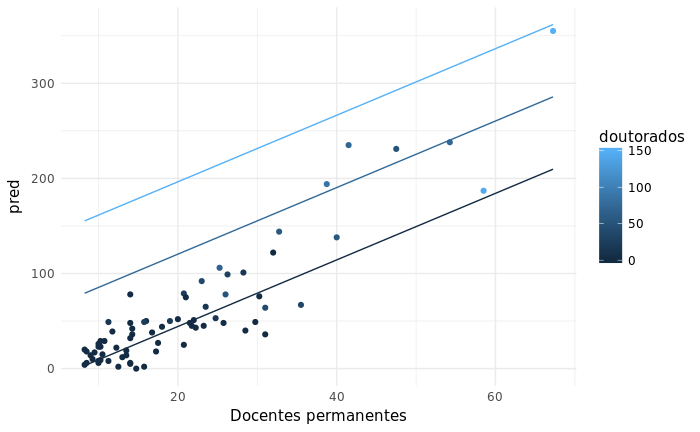

```r
para_plotar_modelo %>%
  ggplot(aes(x = `Docentes permanentes`, y = pred)) +
  geom_line(aes(group = doutorados, colour = doutorados)) +
  # facet_grid(. ~ as.factor(mestrados)) +
  geom_point(data = cacc, aes(y = producao, colour = doutorados))
```

Considerando agora esses três fatores, o que podemos dizer sobre como cada um deles se relaciona com a produção de um programa de pós em CC? E sobre o modelo? Ele explica mais que o modelo 1?

## Agora produtividade

Diferente de medirmos produção (total produzido), é medirmos produtividade (produzido / utilizado). Abaixo focaremos nessa análise. Para isso crie um modelo que investiga como um conjunto de fatores que você julga que são relevantes se relacionam com a produtividade dos programas. Crie um modelo que avalie como *pelo menos 3 fatores* se relacionam com a produtividade de um programa. Pode reutilizar fatores que já definimos e analizamos para produção. Mas cuidado para não incluir fatores que sejam função linear de outros já incluídos (ex: incluir A, B e um tercero C=A+B)

Produza abaixo o modelo e um texto que comente (i) o modelo, tal como os que fizemos antes, e (ii) as implicações - o que aprendemos sobre como funcionam programas de pós no brasil?.

```r
modelo3 = lm(produtividade  ~ doutorados + `Docentes colaboradores` + tem_doutorado, data = cacc)
#`Docentes visitantes`
tidy(modelo3, conf.int = TRUE, conf.level = 0.95)
```

| term | estimate | std.error | statistic | p.value | conf.low | conf.high |
| --- | --- | --- | --- | --- | --- | --- |
| (Intercept) | 1.64478794 | 0.211110924 | 7.7911077 | 4.817486e-11 | 1.223633175 | 2.06594271 |
| doutorados | 0.01743723 | 0.005034843 | 3.4633115 | 9.209024e-04 | 0.007392993 | 0.02748147 |
| `Docentes colaboradores` | -0.02502093 | 0.033603225 | -0.7445991 | 4.590426e-01 | -0.092057531 | 0.04201567 |
| tem_doutoradosim | 1.20526096 | 0.283143309 | 4.2567171 | 6.417654e-05 | 0.640405516 | 1.77011641 |

```r
glance(modelo3)
```

| r.squared | adj.r.squared | sigma | statistic | p.value | df | logLik | AIC | BIC | deviance | df.residual |
| --- | --- | --- | --- | --- | --- | --- | --- | --- | --- | --- |
| 0.5142304 | 0.49311 | 0.9770685 | 24.34755 | 7.398317e-11 | 4 | -99.83214 | 209.6643 | 221.1166 | 65.87174 | 69 |

**(i) EXPLICAÇÃO**: *Regressão múltipla foi utilizada para analisar se o número de alunos de doutorado e número de docentes e se a instituição possuir curso de doutorado tem uma associação com a Produtividade. Os resultados da regressão indicam que um modelo com os 3 preditores no formato VarDep = doutorados + `Docentes colaboradores` + tem_doutorado explicam pelo modelo 50% da variância da variável de resposta (R2 = 0.50). Alunos de doutorado, definida como a quantidade de alunos cursando doutorado nessas instituições, tem (b = [0.0073, 0.027], IC com 95%) relação de intervalos positiva, assim como a variável tem_doutorado, definida com sim quando a instituição tem no programa o curso de doutorado, tendo erro (b = [0.64, 1.77]), com intervalo apresentando valores positivos. No mais, a variável Docentes colaboradores, definida como o número de professore, tem erro (b = [-0.092, 0.042], IC c om 95%) relação de valores positivos e negativos, logo não se pode afirmar sua significância. Assim, a existência de cursos de doutorado nos programas de pós-graduação, pode impactar no modelo, cerca de 1.20 no valor da produtividade e o número de estudantes do curso de doutorado pode influênciar em média 0.017 na produtividade.*

**(ii) EXPLICAÇÃO**: *Com base nos resultados, é possível afirmar que existe uma relação no que diz respeito a produtividade do programa de pós-graduação com a existência de cursos de doutorado de acordo com modelo 3 apresentado acima. Além disso, parece existir uma relaçao entre a produção cientifíca é o número de professores permanente, de acordo com modelo1 e modelo2. Em contrpartida considerando produção cientifíca, não existe um relação positiva em relação ao número de alunos mestrandos e também para o modelo3, não existe relação positiva entre o número de Docentes colaboradores e a produtividade.*